# Ecosystem Service Climate Regulation in Cities | Norway

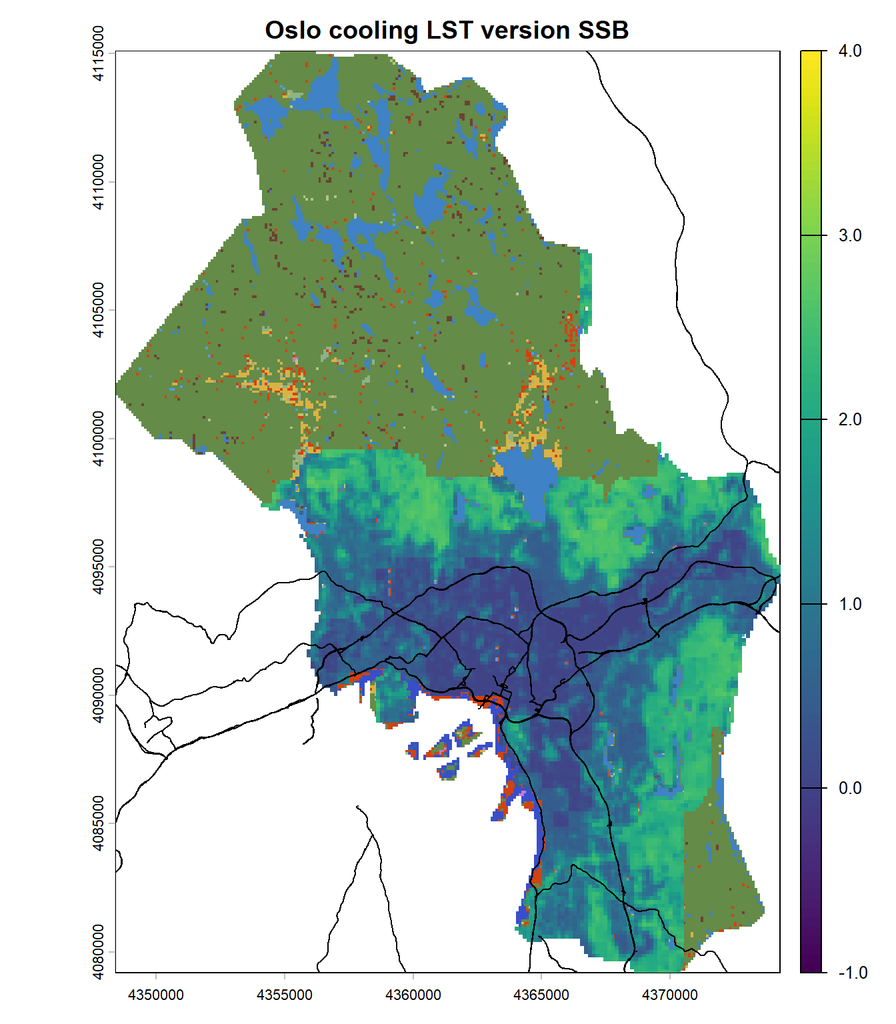

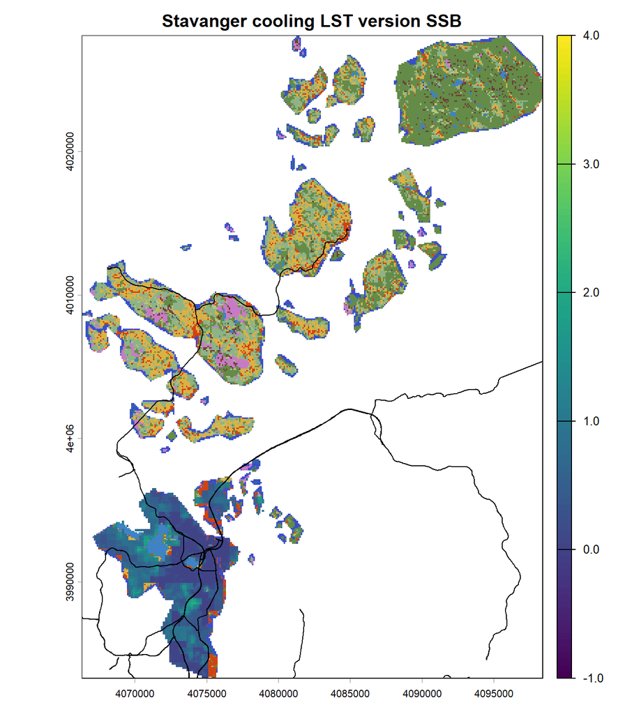

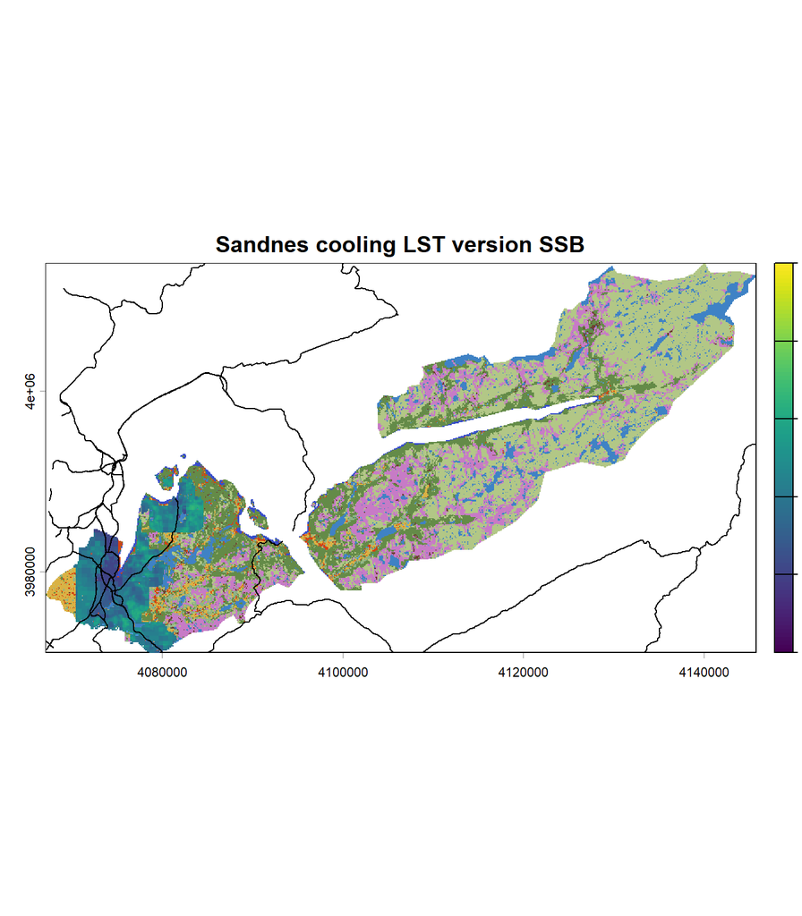

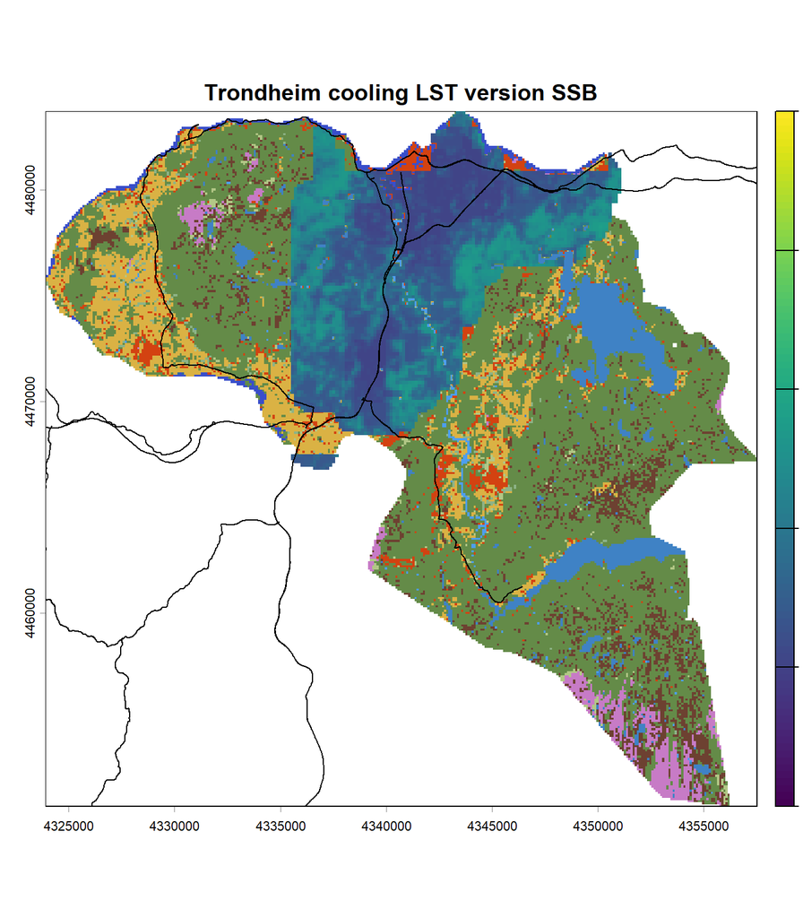

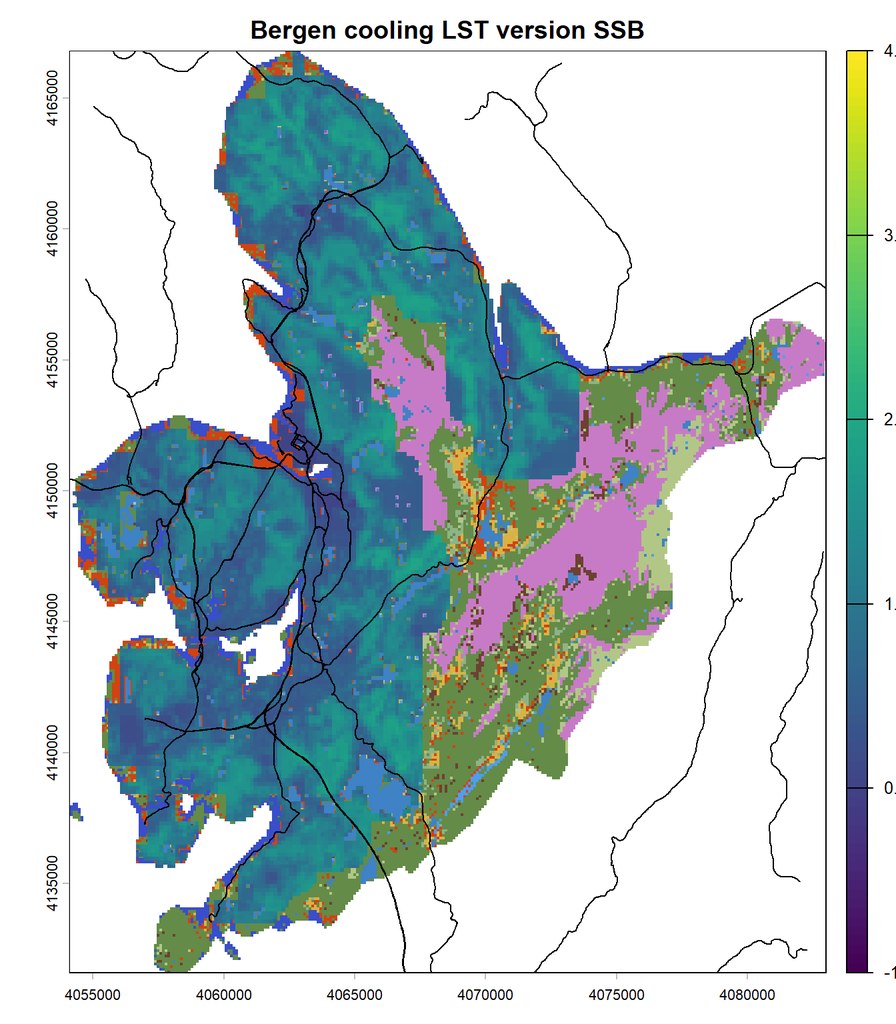

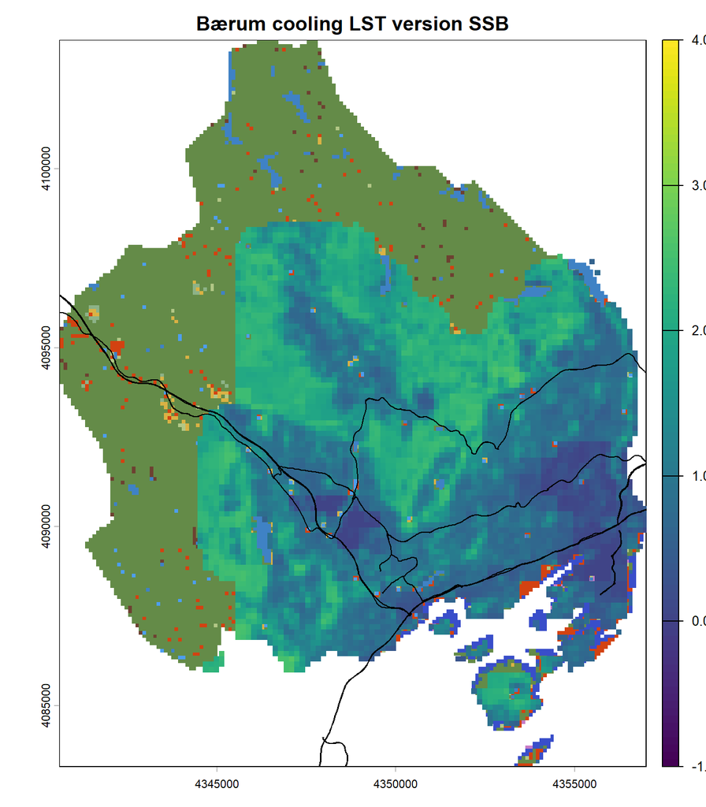

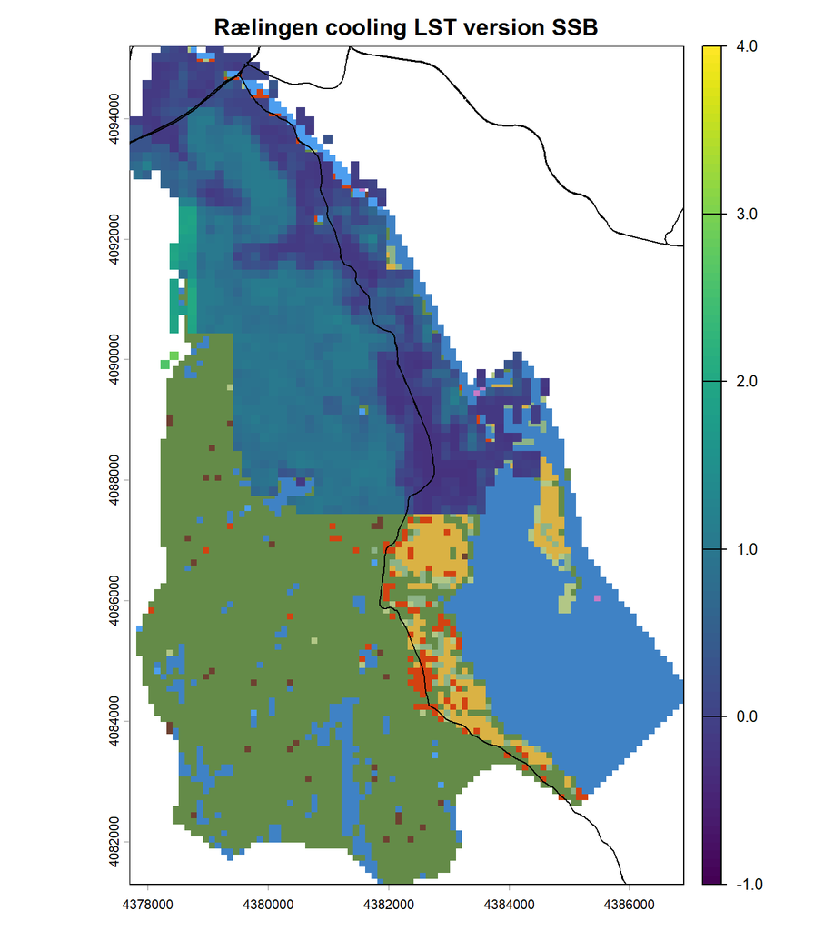

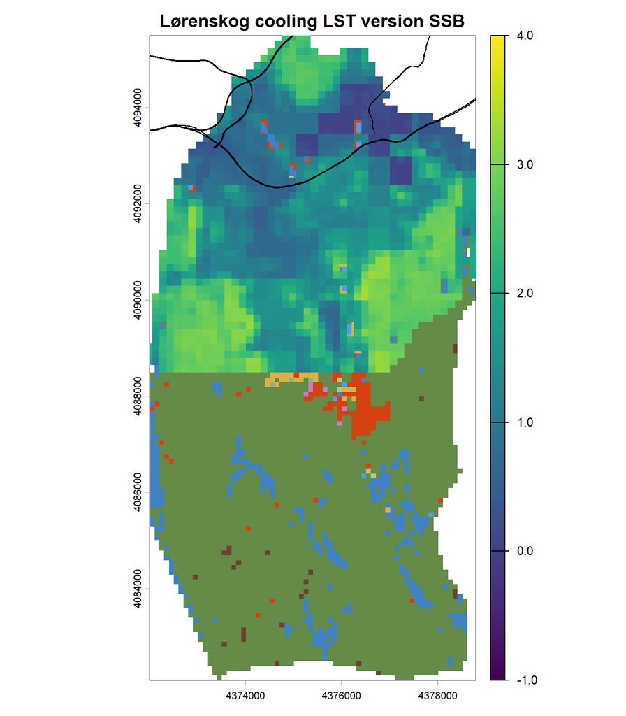

```r
j=1
for(i in 1:nrow(cityb_buf_m)){
  plot(crop(lcm,cityb[i,],mask=T),legend=F,main=paste(cityb_buf$LAU_NAME[i],"cooling","LST version",mdr[j]))
  plot(crop(cooling_stack_n[["SSB"]], cityb_buf[i,],mask=T),range=c(-1,4),add=T,legend=T)
  plot(roads_list[[i]],add=T)
}
```

And here some more plots, just to show the difference to the case where we do not use modifed LST data.

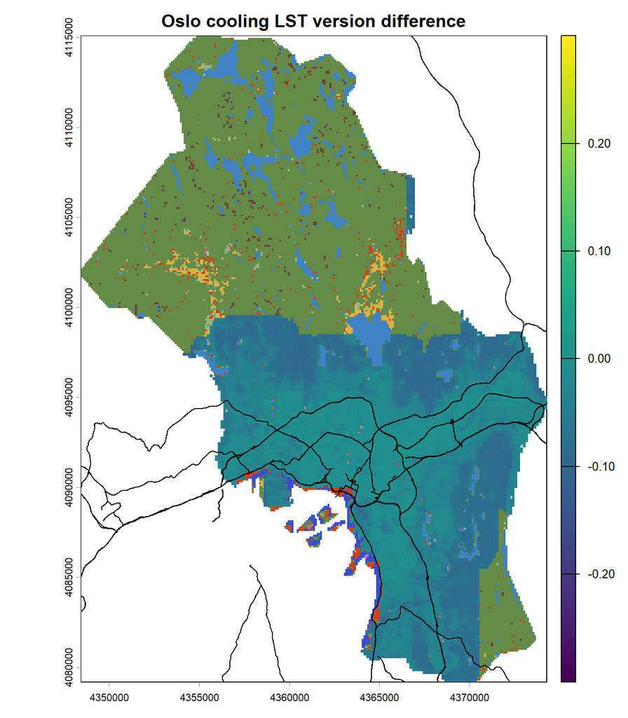

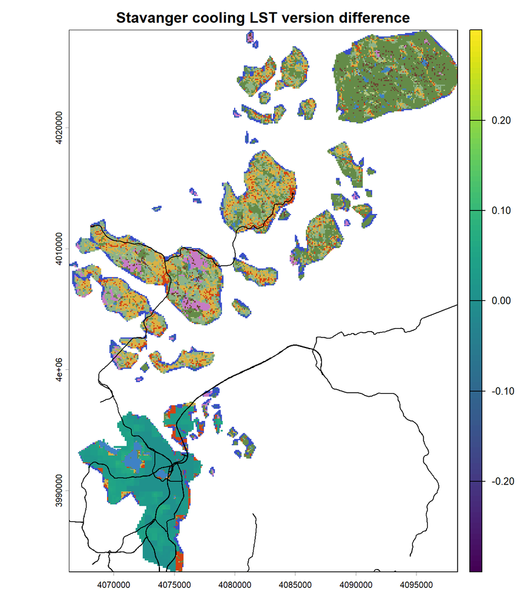

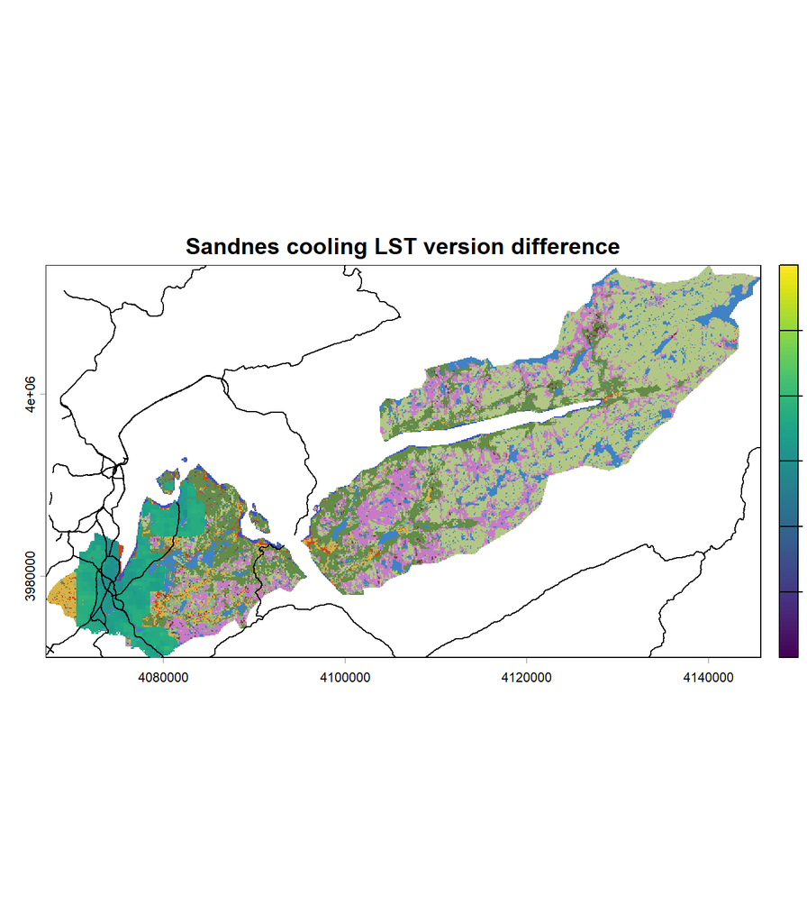

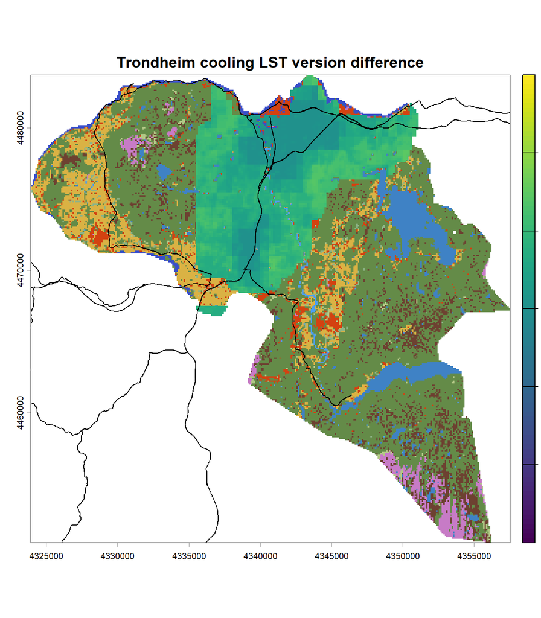

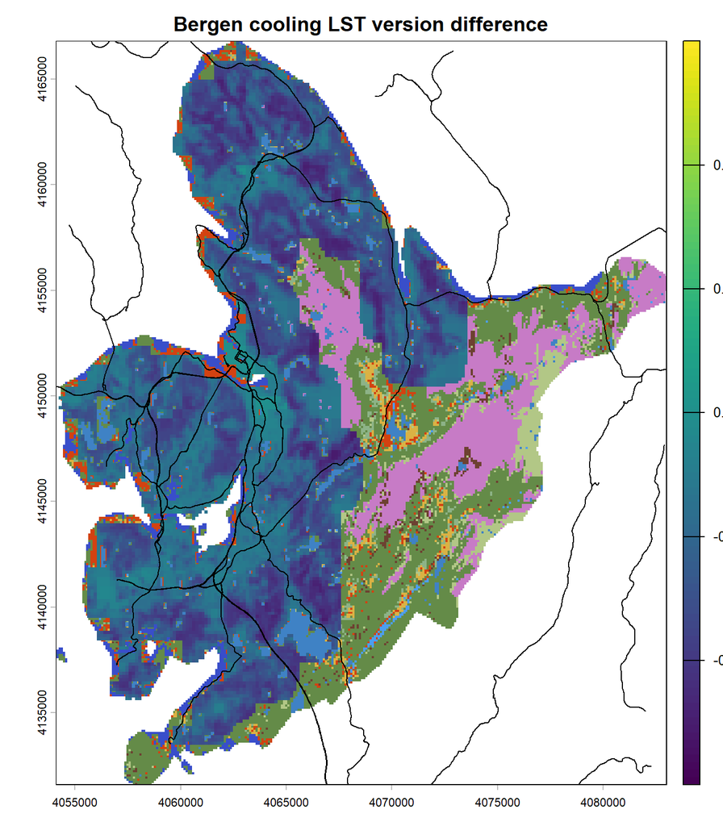

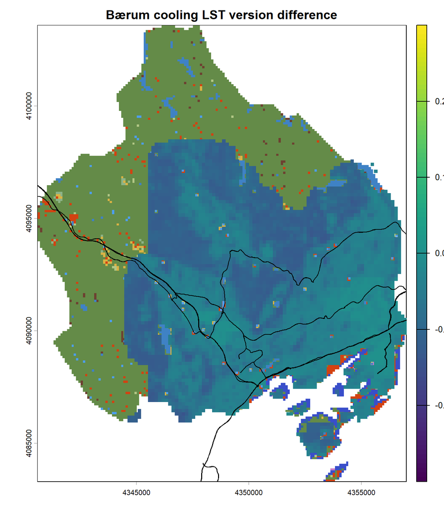

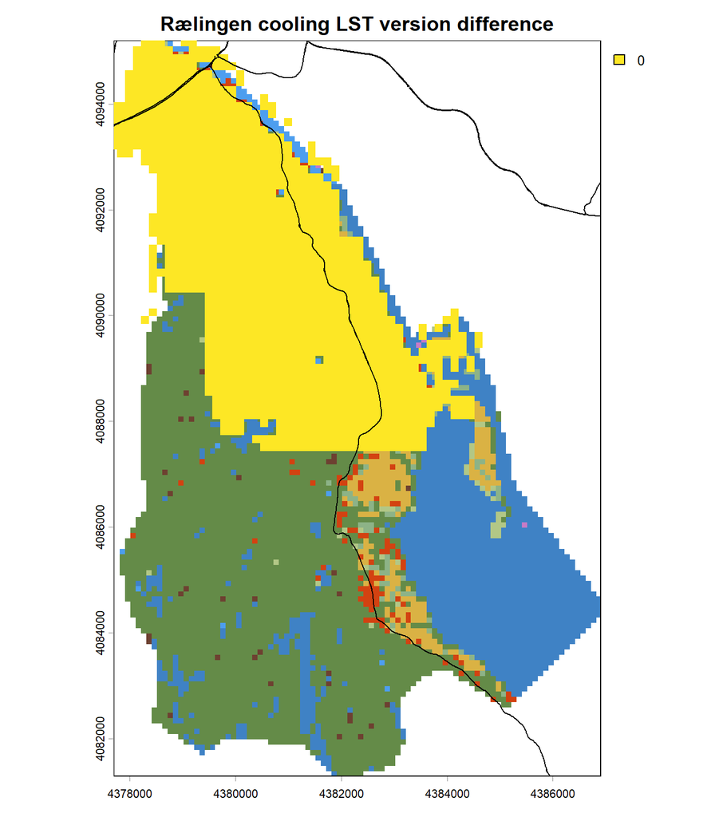

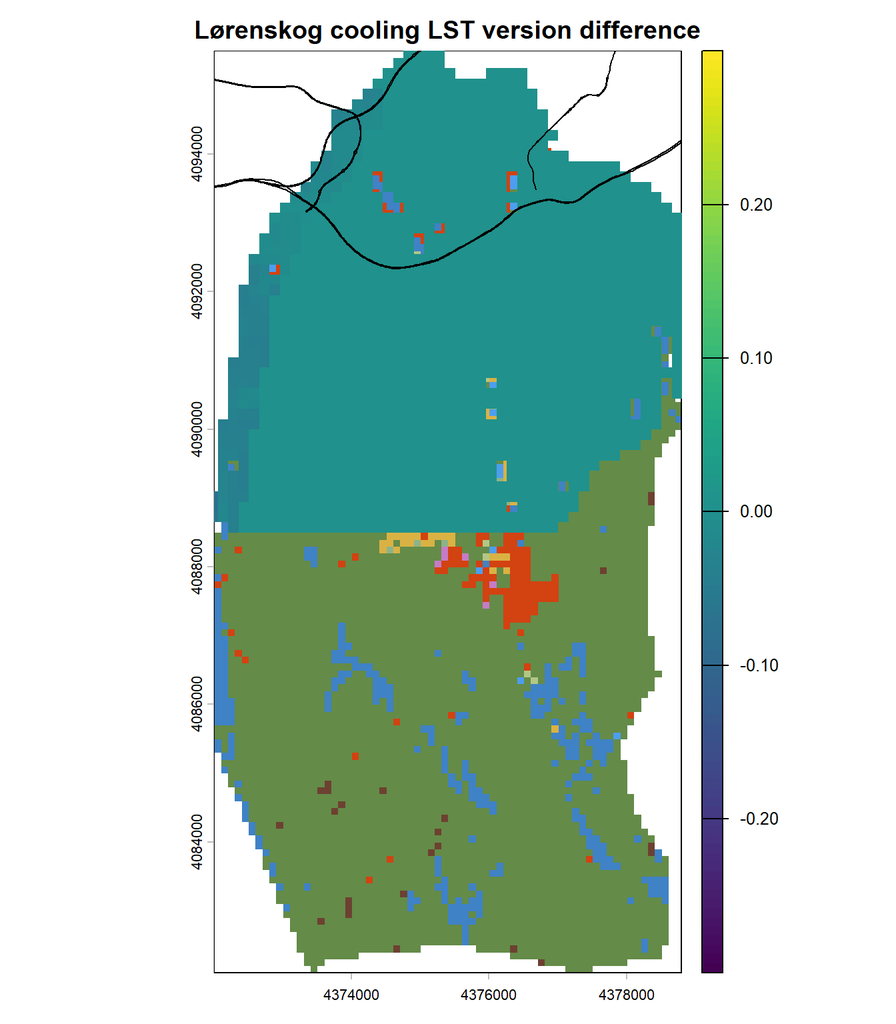

```r
for(i in 1:nrow(cityb_buf_m)){
  plot(crop(lcm,cityb[i,],mask=T),legend=F,main=paste(cityb_buf$LAU_NAME[i],"cooling","LST version difference"))
  plot(crop((cooling_stack_n[[1]]-cooling_stack_n[[2]]), cityb_buf[i,],mask=T),range=c(-0.3,0.3),add=T,legend=T)
  plot(roads_list[[i]],add=T)
}
```

## 6.3 Eurostat deliverables

### 6.3.1 Overview

So here we report:

- Supply tables, by ecosystem, by NUTS2 region, and total NUTS0
- Contribution tables, from ecosystems, by NUTS2 region, and total NUTS0
- Use tables

We use the version based on non-modified LST data (as INCA uses it) and based on non-modified city-LAU-based urban areas.

### 6.3.2 Supply table

The indicators we report in our supply and use tables are what INCA calls “simple average” for the by-ecosystem values and what INCA calls “weighted average” for cooling across all ecosystem types.

```r
gc()
# now cooling by nuts and ecosystem
# Import Norway NUTs2 shape
n2shp<-terra::vect(file.path(d_fp,"Norway_files","NUTS2021_NO_LVL2_wosvalbard","NUTS2021_NO_LVL2_wos.shp"))
n2shp <- project(n2shp,crs(lcm))
# rasterize the shape
n2r_no <- terra::rasterize(n2shp,mask_stack,field="NUTS_ID")
# now make a loop across lst versions
stl<-list()
for(j in 1:length(mdr)){
  # Step 1: Make a stack of the relevant data and move it into a dataframe
  astack <- c(
  terra::crop(cooling_stack_e[[j]],lcm2),
  n2r_no,
  lcm2)
  names(astack)<-c("cooling","region","lcm")
  adf<-as.data.frame(astack)
  clean_adf <- adf %>% drop_na()
  # Step 2: Retrieve all the different summary statistics we want
  # means by region and ecosystem type
  mean_by_region_es <- clean_adf %>%
    group_by(region,lcm) %>%
    summarise(cooling = mean(cooling))
  mean_by_es <- clean_adf %>%
    select(-region) %>%
    group_by(lcm) %>%
    summarise(cooling = mean(cooling)) %>%
    mutate(region = "NO") %>%
    relocate(region,.before=lcm)
  # total means by NUTS2
  mean_by_region <- clean_adf %>%
    group_by(region) %>%
    summarise(cooling = mean(cooling)) %>%
    mutate(lcm="All") %>%
    relocate(lcm,.after=region)
  # total mean for the whole country NUTS0
  mean_overall <- clean_adf %>% select(cooling) %>%
    summarise(cooling=mean(cooling)) %>%
    mutate(region = "NO",lcm = "All") %>%
    relocate(cooling,.after =lcm)
  # put together
  mean_vals <- rbind(mean_by_es,mean_overall,mean_by_region_es,mean_by_region) %>%
    filter(region !="NO09") %>%
    pivot_wider(names_from=lcm,values_from = cooling) %>%
    left_join(n2shp %>% as.data.frame() %>% select(NUTS_ID,NUTS_NAME),
            by = join_by(region == NUTS_ID)) %>%
    rename(Name = NUTS_NAME) %>%
    relocate(Name,.after=region) %>%
    rename(Region = region)
  mean_vals$Name[mean_vals$Region=="NO"]<-"Norge"
  # put into our list
  stl[[j]]<-mean_vals
  # Step 3: clean up
  rm(astack,adf,clean_adf,mean_overall,mean_by_region,mean_by_es,mean_by_region_es,mean_vals)
}
names(stl)<-mdr
stl_e<-stl
rm(stl)
```

Here are the results.

```r
kable(stl_e[["INCA"]] %>% mutate(across(where(is.numeric), ~ round(.x, 2))))
```

| Region | Name | Settlements and other artificial areas | Cropland | Grassland | Forest and woodlands | Heathlands and shrub | Sparsely vegetated ecosystems | Inland wetlands | Coastal beaches, dunes and wetlands | All |
| --- | --- | --- | --- | --- | --- | --- | --- | --- | --- | --- |
| NO | Norge | 0.48 | 0.55 | 0.78 | 1.26 | 0.29 | 0.15 | 0.61 | 0.67 | 0.78 |
| NO06 | Trøndelag | 0.20 | 0.26 | 0.44 | 0.62 | 0.10 | 0.27 | 0.36 | 0.35 | 0.47 |
| NO08 | Oslo og Viken | 0.62 | 0.90 | 1.06 | 1.98 | 0.70 | 0.87 | 1.76 | 0.89 | 1.56 |
| NO0A | Vestlandet | 0.44 | 0.63 | 0.79 | 0.90 | 0.29 | 0.13 | 0.74 | 0.69 | 0.51 |

### 6.3.3 Contribution table

To show how different ecosystems contribute to total cooling in each region, we construct seperate tables to show a decomposition of the (weighted) averages reported in the above section. This is what INCA calls “weighted average” for the by-ecosystem values. The decomposed values are not very insightful on their own, because they reflect the proportion of different ecosystems in each region (if the region consists predominantly of forest, forest will have the largest contribution to cooling). The cooling effectiveness of different ecosystems is better captured by the values reported in the previous section.

```r
gc()
# decomposed total cooling by ecosystem for each region
# now make a loop across lst versions
cstl<-list()
for(j in 1:length(mdr)){
  # Step 1: Make a stack of the relevant data and move it into a dataframe
astack <- c(
  terra::crop(cooling_stack_e[[j]],lcm2),
  n2r_no,
  lcm2)
names(astack)<-c("cooling","region","lcm")
adf<-as.data.frame(astack)
clean_adf <- adf %>% drop_na()
# Step 2: Retrieve all the different summary statistics we want
# means by region and ecosystem type
mean_by_region_es <- clean_adf %>%
  group_by(region,lcm) %>%
  summarise(cooling = mean(cooling))
mean_by_es <- clean_adf %>%
  select(-region) %>%
  group_by(lcm) %>%
  summarise(cooling = mean(cooling)) %>%
  mutate(region = "NO") %>%
  relocate(region,.before=lcm)
# weights
weights_by_region_es<-clean_adf %>% group_by(region) %>% count(lcm) %>% mutate(weight = n/sum(n)) %>% ungroup()
weights_overall_es<-clean_adf %>% count(lcm) %>% mutate(weight = n/sum(n)) %>% ungroup()

# put together
decomp_by_region_es <- mean_by_region_es %>% left_join(weights_by_region_es) %>%
  mutate(dcmp_cooling = cooling * weight)
decomp_overall_es <- mean_by_es %>% left_join(weights_overall_es) %>%
  mutate(dcmp_cooling = cooling * weight)
decomp_vals <- rbind(decomp_overall_es,decomp_by_region_es) %>%
  filter(region !="NO09") %>%
  select(-c(n,weight,cooling)) %>%
  pivot_wider(names_from=lcm,values_from = dcmp_cooling) %>%
  left_join(n2shp %>% as.data.frame() %>% select(NUTS_ID,NUTS_NAME),
            by = join_by(region == NUTS_ID)) %>%
  rename(Name = NUTS_NAME) %>%
  relocate(Name,.after=region) %>%
  rename(Region = region) %>%
  mutate(All = rowSums(across(`Settlements and other artificial areas`:`Coastal beaches, dunes and wetlands`)))
decomp_vals$Name[decomp_vals$Region=="NO"]<-"Norge"
  # put into our list
  cstl[[j]]<-decomp_vals
  # Step 3: clean up
  rm(astack,adf,clean_adf,mean_by_es,mean_by_region_es,decomp_vals,decomp_overall_es,decomp_by_region_es,weights_overall_es,weights_by_region_es)
}
names(cstl)<-mdr
cstl_e<-cstl
rm(cstl)
```

Here are the results

```r
kable(cstl_e[["INCA"]] %>% mutate(across(where(is.numeric), ~ round(.x, 2))))
```

| Region | Name | Settlements and other artificial areas | Cropland | Grassland | Forest and woodlands | Heathlands and shrub | Sparsely vegetated ecosystems | Inland wetlands | Coastal beaches, dunes and wetlands | All |
| --- | --- | --- | --- | --- | --- | --- | --- | --- | --- | --- |
| NO | Norge | 0.07 | 0.04 | 0.03 | 0.57 | 0.03 | 0.02 | 0.02 | 0 | 0.78 |
| NO06 | Trøndelag | 0.03 | 0.03 | 0.01 | 0.36 | 0.00 | 0.00 | 0.03 | 0 | 0.47 |
| NO08 | Oslo og Viken | 0.16 | 0.04 | 0.01 | 1.33 | 0.00 | 0.01 | 0.01 | 0 | 1.56 |
| NO0A | Vestlandet | 0.05 | 0.05 | 0.04 | 0.27 | 0.05 | 0.04 | 0.01 | 0 | 0.51 |

### 6.3.4 Use table

```r
utl<-list()
for(j in 1:length(mdr)){
  utl[[j]]<-stl_e[[j]] %>%
    select(c(Region,Name,All)) %>%
    mutate(`Intermediate consumption by industries` = NA) %>%
    mutate(`Government final consumption` = NA) %>%
    mutate(`Households final consumption` = All) %>%
    mutate(`Gross capital formation` = NA) %>%
    mutate(Exports = NA) %>%
    rename(Total = All)
}
names(utl)<-mdr
utl_e<-utl
rm(utl)
```

Here are the results.

```r
kable(utl_e[["INCA"]] %>% mutate(across(where(is.numeric), ~ round(.x, 2))))
```

| Region | Name | Total | Intermediate consumption by industries | Government final consumption | Households final consumption | Gross capital formation | Exports |
| --- | --- | --- | --- | --- | --- | --- | --- |
| NO | Norge | 0.78 | NA | NA | 0.78 | NA | NA |
| NO06 | Trøndelag | 0.47 | NA | NA | 0.47 | NA | NA |
| NO08 | Oslo og Viken | 1.56 | NA | NA | 1.56 | NA | NA |
| NO0A | Vestlandet | 0.51 | NA | NA | 0.51 | NA | NA |

## 6.4 National deliverables

### 6.4.1 Overview

Here we report:

- Supply tables, by ecosystem, and by city
- Contribution tables, by ecosystem, and by city

Here we use the version based on modified LST data and modified urban areas.

### 6.4.2 Supply table

Same as in the previous section, but based on stricter urban definition, based on modified LST data, and aggregation to cities, rather than NUTS shapes.

```r
gc()
# rasterize the city shape
cityr_no <- terra::rasterize(cityb_buf_m,mask_stack,field="LAU_ID")
# need to extend the stricter version so it is as large as the previous map
# this just adds NA colums on the right and on the left.
cooling_stack_n <- extend(
  cooling_stack_n,
  ext(cooling_stack_e)
)
# now make a loop across LST versions
stl<-list()
for(j in 1:length(mdr)){
  # Step 1: Make a stack of the relevant data and move it into a dataframe
  astack <- c(
  terra::crop(cooling_stack_n[[j]],lcm2),
  cityr_no,
  lcm2)
  names(astack)<-c("cooling","city","lcm")
  adf<-as.data.frame(astack)
  clean_adf <- adf %>% drop_na()
  # Step 2: Retrieve all the different summary statistics we want
  # means by city and ecosystem type
  mean_by_city_es <- clean_adf %>%
    group_by(city,lcm) %>%
    summarise(cooling = mean(cooling))
  # total means by NUTS2
  mean_by_city <- clean_adf %>%
    group_by(city) %>%
    summarise(cooling = mean(cooling)) %>%
    mutate(lcm="All") %>%
    relocate(lcm,.after=city)
  # put together
  mean_vals <- rbind(mean_by_city_es,mean_by_city) %>%
    pivot_wider(names_from=lcm,values_from = cooling) %>%
    left_join(cityb_buf_m %>% as.data.frame() %>% select(LAU_ID,LAU_NAME),
            by = join_by(city == LAU_ID)) %>%
    rename(Name = LAU_NAME) %>%
    relocate(Name,.after=city) %>%
    rename(City = city) %>%
    arrange(match(Name, cityb_buf_m$LAU_NAME))
  # put into our list
  stl[[j]]<-mean_vals
  # Step 3: clean up
  rm(astack,adf,clean_adf,mean_by_city,mean_by_city_es,mean_vals)
}
names(stl)<-mdr
stl_n<-stl
rm(stl)
```

Here are the results.

```r
kable(stl_n[["SSB"]] %>% mutate(across(where(is.numeric), ~ round(.x, 2))))
```

| City | Name | Settlements and other artificial areas | Cropland | Grassland | Forest and woodlands | Heathlands and shrub | Sparsely vegetated ecosystems | Inland wetlands | Coastal beaches, dunes and wetlands | All |
| --- | --- | --- | --- | --- | --- | --- | --- | --- | --- | --- |
| 301 | Oslo | 0.55 | 1.22 | 1.59 | 1.97 | 0.84 | 0.93 | 1.68 | NA | 1.13 |
| 1103 | Stavanger | 0.32 | 0.69 | 0.94 | 0.96 | 0.71 | 0.51 | 1.13 | 0.62 | 0.48 |
| 1108 | Sandnes | 0.59 | 1.09 | 1.11 | 1.38 | 1.07 | 1.03 | 1.29 | 0.87 | 1.03 |
| 5001 | Trondheim | 0.36 | 0.60 | 0.86 | 1.16 | 0.28 | 0.56 | 1.04 | 0.83 | 0.71 |
| 4601 | Bergen | 0.62 | 0.94 | 1.14 | 1.21 | 0.80 | 0.87 | 1.12 | 0.62 | 0.97 |
| 3024 | Bærum | 0.84 | 1.10 | 1.55 | 1.88 | 0.80 | 0.92 | 1.85 | 0.87 | 1.33 |
| 3027 | Rælingen | 0.10 | -0.02 | 0.01 | 0.79 | -0.08 | 0.03 | 0.28 | NA | 0.50 |
| 3029 | Lørenskog | 0.97 | 1.55 | 1.88 | 2.35 | 1.14 | 1.28 | 2.30 | NA | 1.66 |

### 6.4.3 Contribution table

Same as in the previous version, but now based on strict urban areas.

```r
gc()
# decomposed total cooling by ecosystem for each region
# now make a loop across LST versions
cstl<-list()
for(j in 1:length(mdr)){
  # Step 1: Make a stack of the relevant data and move it into a dataframe
astack <- c(
  terra::crop(cooling_stack_n[[j]],lcm2),
  cityr_no,
  lcm2)
names(astack)<-c("cooling","city","lcm")
adf<-as.data.frame(astack)
clean_adf <- adf %>% drop_na()
# Step 2: Retrieve all the different summary statistics we want
# means by city and ecosystem type
mean_by_city_es <- clean_adf %>%
  group_by(city,lcm) %>%
  summarise(cooling = mean(cooling))
# weights
weights_by_city_es<-clean_adf %>% group_by(city) %>% count(lcm) %>% mutate(weight = n/sum(n)) %>% ungroup()

# put together
decomp_by_city_es <- mean_by_city_es %>% left_join(weights_by_city_es) %>%
  mutate(dcmp_cooling = cooling * weight)
decomp_vals <- rbind(decomp_by_city_es) %>%
  select(-c(n,weight,cooling)) %>%
  pivot_wider(names_from=lcm,values_from = dcmp_cooling) %>%
  left_join(cityb_buf_m %>% as.data.frame() %>% select(LAU_ID,LAU_NAME),
            by = join_by(city == LAU_ID)) %>%
  rename(Name = LAU_NAME) %>%
  relocate(Name,.after=city) %>%
  rename(City = city) %>%
  mutate(All = rowSums(across(`Settlements and other artificial areas`:`Coastal beaches, dunes and wetlands`),na.rm=T)) %>%
    arrange(match(Name, cityb_buf_m$LAU_NAME))
  # put into our list
  cstl[[j]]<-decomp_vals
  # Step 3: clean up
  rm(astack,adf,clean_adf,mean_by_city_es,decomp_vals,decomp_by_city_es,weights_by_city_es)
}
names(cstl)<-mdr
cstl_n<-cstl
rm(cstl)
```

Here are the contribution results.

```r
kable(cstl_n[["SSB"]] %>% mutate(across(where(is.numeric), ~ round(.x, 2))))
```

| City | Name | Settlements and other artificial areas | Cropland | Grassland | Forest and woodlands | Heathlands and shrub | Sparsely vegetated ecosystems | Inland wetlands | Coastal beaches, dunes and wetlands | All |
| --- | --- | --- | --- | --- | --- | --- | --- | --- | --- | --- |
| 301 | Oslo | 0.31 | 0.02 | 0.00 | 0.77 | 0.00 | 0.02 | 0.00 | NA | 1.13 |
| 1103 | Stavanger | 0.21 | 0.12 | 0.02 | 0.11 | 0.00 | 0.02 | 0.00 | 0 | 0.48 |
| 1108 | Sandnes | 0.17 | 0.25 | 0.10 | 0.38 | 0.04 | 0.07 | 0.02 | 0 | 1.03 |
| 5001 | Trondheim | 0.15 | 0.08 | 0.02 | 0.43 | 0.00 | 0.02 | 0.02 | 0 | 0.71 |
| 4601 | Bergen | 0.19 | 0.04 | 0.03 | 0.62 | 0.06 | 0.02 | 0.01 | 0 | 0.97 |
| 3024 | Bærum | 0.34 | 0.12 | 0.01 | 0.83 | 0.01 | 0.03 | 0.00 | 0 | 1.33 |
| 3027 | Rælingen | 0.02 | 0.00 | 0.00 | 0.47 | 0.00 | 0.00 | 0.00 | NA | 0.50 |
| 3029 | Lørenskog | 0.37 | 0.24 | 0.01 | 0.99 | 0.01 | 0.04 | 0.00 | NA | 1.66 |

# 7. Ideas for improvements

Several ideas, including:

- Use alternative LST data with better coverage. The current Lst data have been masked to city LAUs. If we had unmasked data, we could include all towns in the computation as well. This would increase the sample from 8 municipalities to up to 75 municipalities. It would provide more detailed and regionally varying information, and it would also create more representative results at the aggregate NUTS2 and NUTS0 level.
- Include more controls in the regression models. To change the cooling results, the controls would have to capture something that is currently (unintentionally) captured by vegetation. Most importantly NDVI, which captures more types of vegetation than only trees. DESTATIS in Germany has found out that this additional predictor makes the largest difference.
- Once available, consider using European weather station data to estimate the coefficients of the second model.